# IE 360 HW 2

#ANOTHER VARIABLES

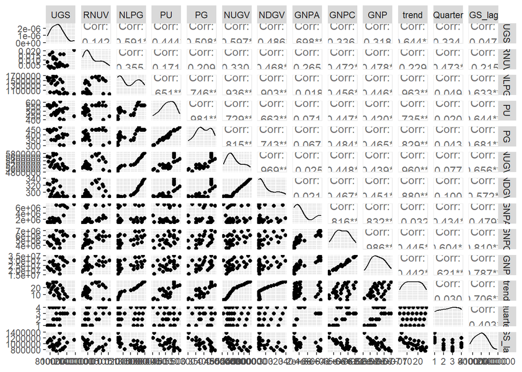

```r
options(repr.plot.width=14, repr.plot.height=10)
dt$Quarter = as.numeric(dt$Quarter)
ggpairs(dt[3:28,2:14])
```

```r
dt$Quarter = as.factor(dt$Quarter)
```

#Adding the highest correlation variable with UGS it is another option.But all of them shouldn’t have very high correlations with the already added variables. #Adding PU since it is the highest Radj: 0.9464

```r
options(repr.plot.width=12, repr.plot.height=8)
model.addpu <- lm(UGS~trend+Quarter+UGS_lag2+PU, dt[m])
summary(model.addpu)
```

```
##
## Call:
## lm(formula = UGS ~ trend + Quarter + UGS_lag2 + PU, data = dt[m])
##
## Residuals:
##    Min     1Q Median     3Q    Max
## -61183 -18461   1605  19631  52416
##
## Coefficients:
##               Estimate Std. Error t value Pr(>|t|)
## (Intercept)  6.559e+05  2.509e+05   2.614  0.01705 *
## trend       -3.019e+03  2.652e+03  -1.138  0.26908
## Quarter2     2.248e+05  3.828e+04   5.874 1.17e-05 ***
## Quarter3     4.240e+05  4.982e+04   8.511 6.60e-08 ***
## Quarter4     1.760e+05  3.213e+04   5.478 2.76e-05 ***
## UGS_lag2     4.445e-01  1.665e-01   2.669  0.01517 *
## PU          -5.624e+02  1.959e+02  -2.871  0.00979 **
## ---
## Signif. codes:  0 '***' 0.001 '**' 0.01 '*' 0.05 '.' 0.1 ' ' 1
##
## Residual standard error: 34220 on 19 degrees of freedom
##   (2 observations deleted due to missingness)
## Multiple R-squared:  0.9592, Adjusted R-squared:  0.9464
## F-statistic: 74.52 on 6 and 19 DF,  p-value: 3.513e-12
```

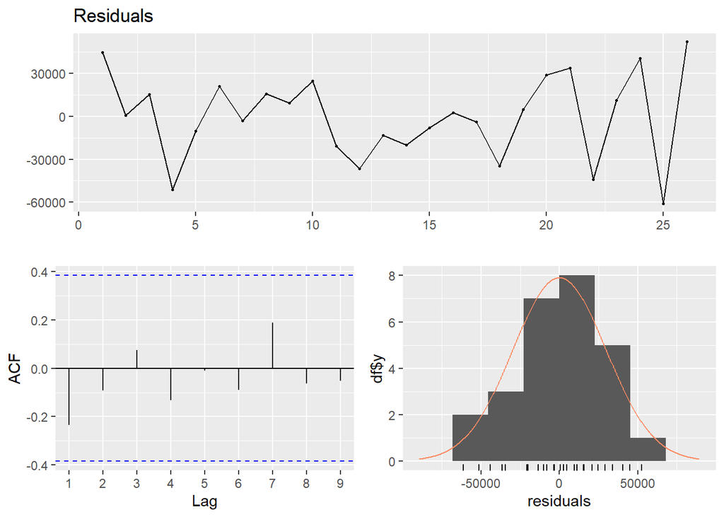

```
##
##  Breusch-Godfrey test for serial correlation of order up to 10
##
## data:  Residuals
## LM test = 7.5069, df = 10, p-value = 0.6769
```

```r
checkresiduals(model.addpu)
```

#The p values are significant but trend’ is less significant. #The residuals looks randomly and normally distributed.ACF graphs look great, no any lag excess the limits

# Removing trend

```r
model.remove <- lm(UGS~Quarter+UGS_lag2+PU, dt[m])
summary(model.remove)
```

```
##
## Call:
## lm(formula = UGS ~ Quarter + UGS_lag2 + PU, data = dt[m])
##
## Residuals:
##    Min     1Q Median     3Q    Max
## -70633 -10616   -390  29231  39933
##
## Coefficients:
##               Estimate Std. Error t value Pr(>|t|)
## (Intercept)  4.567e+05  1.811e+05   2.522  0.02026 *
## Quarter2     2.579e+05  2.510e+04  10.274 2.01e-09 ***
## Quarter3     4.708e+05  2.836e+04  16.601 3.66e-13 ***
## Quarter4     2.008e+05  2.375e+04   8.455 4.91e-08 ***
## UGS_lag2     6.071e-01  8.616e-02   7.047 7.81e-07 ***
## PU          -6.322e+02  1.875e+02  -3.372  0.00303 **
## ---
## Signif. codes:  0 '***' 0.001 '**' 0.01 '*' 0.05 '.' 0.1 ' ' 1
##
## Residual standard error: 34480 on 20 degrees of freedom
##   (2 observations deleted due to missingness)
## Multiple R-squared:  0.9565, Adjusted R-squared:  0.9456
## F-statistic: 87.86 on 5 and 20 DF,  p-value: 6.542e-13
```

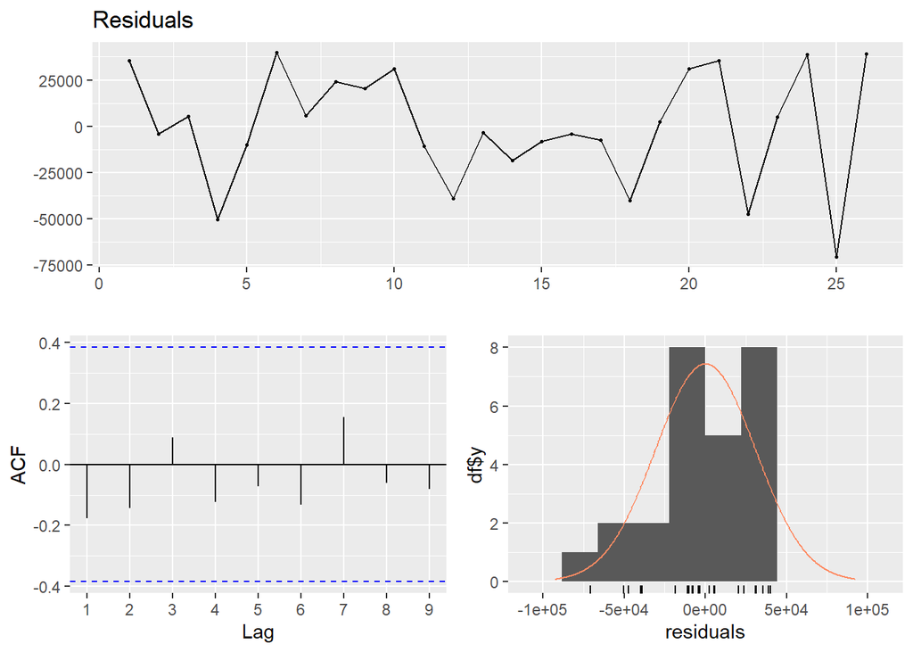

```
##
##  Breusch-Godfrey test for serial correlation of order up to 9
##
## data:  Residuals
## LM test = 8.6494, df = 9, p-value = 0.4702
```

```r
checkresiduals(model.remove)
```

#Removing trend reduce R adjusted square and the residual histogram is worse than previous

#FINAL MODEL

```r
model.final = model.addpu
summary(model.final)
```

```
##
## Call:
## lm(formula = UGS ~ trend + Quarter + UGS_lag2 + PU, data = dt[m])
##
## Residuals:
##    Min     1Q Median     3Q    Max
## -61183 -18461   1605  19631  52416
##
## Coefficients:
##               Estimate Std. Error t value Pr(>|t|)
## (Intercept)  6.559e+05  2.509e+05   2.614  0.01705 *
## trend       -3.019e+03  2.652e+03  -1.138  0.26908
## Quarter2     2.248e+05  3.828e+04   5.874 1.17e-05 ***
## Quarter3     4.240e+05  4.982e+04   8.511 6.60e-08 ***
## Quarter4     1.760e+05  3.213e+04   5.478 2.76e-05 ***
## UGS_lag2     4.445e-01  1.665e-01   2.669  0.01517 *
## PU          -5.624e+02  1.959e+02  -2.871  0.00979 **
## ---
## Signif. codes:  0 '***' 0.001 '**' 0.01 '*' 0.05 '.' 0.1 ' ' 1
##
## Residual standard error: 34220 on 19 degrees of freedom
##   (2 observations deleted due to missingness)
## Multiple R-squared:  0.9592, Adjusted R-squared:  0.9464
## F-statistic: 74.52 on 6 and 19 DF,  p-value: 3.513e-12
```

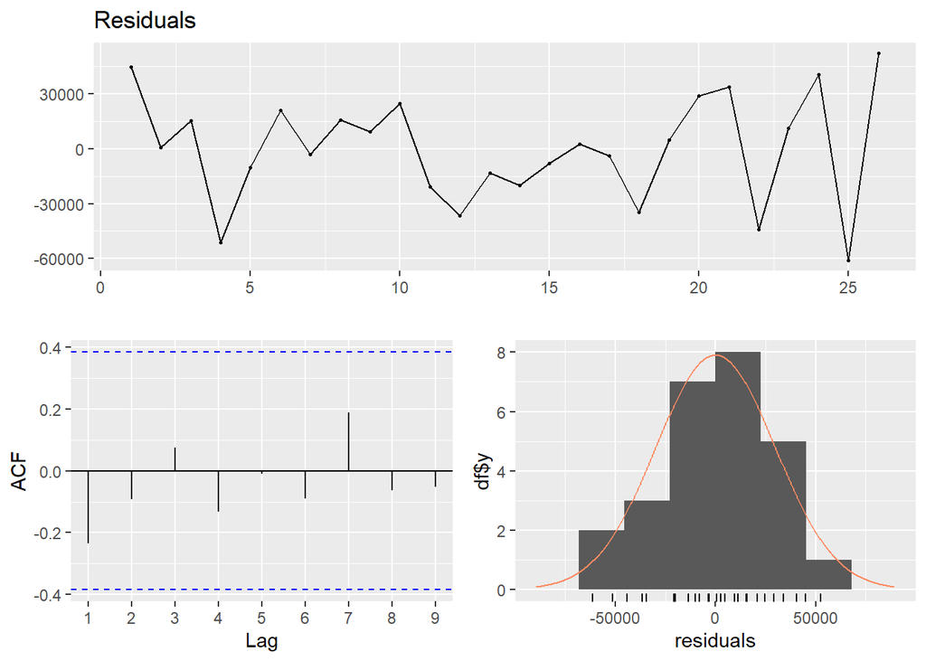

```
##
##  Breusch-Godfrey test for serial correlation of order up to 10
##
## data:  Residuals
## LM test = 7.5069, df = 10, p-value = 0.6769
```

```r
checkresiduals(model.final)
```

```r
X = dt[,c(12,13,14,5)]
y = data.table(cbind(trend=1:32,UGS_Predicted=c(rep(NA,2),model.final$fitted.values,rep(0,4))))
tail(X)
```

```
##    trend Quarter UGS_lag2     PU
## 1:    27       3   736580 565.19
## 2:    28       4   877614 565.19
## 3:    29       1   946783 565.19
## 4:    30       2   872000 565.19
## 5:    31       3       NA 565.19
## 6:    32       4       NA 565.19
```

#due to na values for 31 and 32 we can use the predicted lagged values

```r
X[31,3] = y[29,2] = predict(model.final, X[29,])
X[32,3] = y[30,2] = predict(model.final, X[30,])
y[31,2] = predict(model.final, X[31,])
y[32,2] = predict(model.final, X[32,])
y[29:32]#forecast for these values
```

```
##    trend UGS_Predicted
## 1:    29      671312.0
## 2:    30      859897.9
## 3:    31      966879.4
## 4:    32      799632.5
```

```r
data.plot = cbind(Time=dt$Time,y,UGS=dt$UGS)
head(data.plot,3)
```

```
##       Time trend UGS_Predicted     UGS
## 1: 2000_Q1     1            NA 1128971
## 2: 2000_Q2     2            NA 1199569
## 3: 2000_Q3     3       1325256 1370167
```

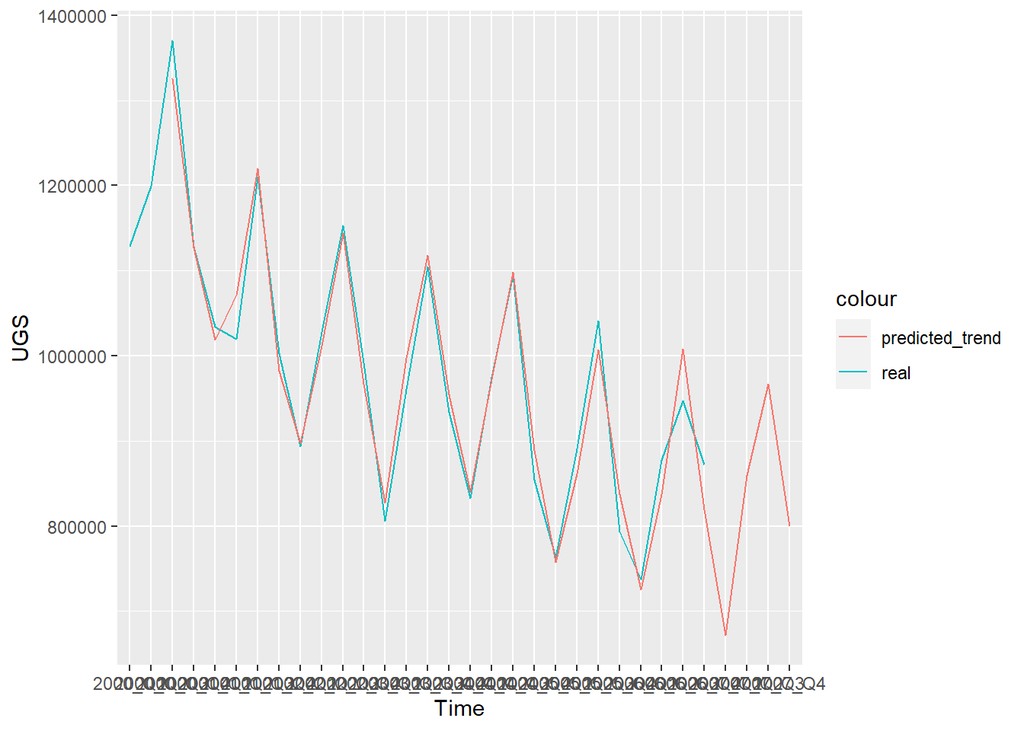

```r
options(repr.plot.width=18, repr.plot.height=6)
ggplot(data.plot ,aes(x=Time, group=1)) +
  geom_line(aes(y=UGS,color='real')) +
  geom_line(aes(y=UGS_Predicted,color='predicted_trend'))
```

# CONCLUSION

#The purpose of this homework is to show UGS values with related to several independent variables.Building a model of regression for forecasting. The final model suggested that UGS depends on seasonality, trend,PU and lag2 variables.